# Estructura Poblacional

Claudia1930

2022-11-23

[figure not shown]

```r
knitr::include_graphics("QUETA.jpg")
```

# Introducción

La base de datos con la cual se trabajará, corresponde a un proceso de investigación/extensión con el objetivo de determinar la Estructura Poblacional de las llamas en la Argentina.

La Estructura Poblacional es una herramienta demográfica que consiste en realizar un relevamiento poblacional basándose en caracteres zootécnicos de los animales presentes en diferentes tropas a nivel de una determinada área y/o región. La metodología mencionada tiene como principal objetivo determinar las principales características de “LA LLAMA ARGENTINA” y su POTENCIAL PRODUCTIVO. En este caso, la caracterización y cuantificación de la oferta poblacional se realiza en la comunidades Aborígenes de la Provincia de Jujuy, más precisamente en los departamentos de Rinconada, Cochinoca y Yavi.

## Exploración de los datos

```r
BD_General <- read_excel("BD_General.xlsx",
    col_types = c("numeric", "text", "numeric",
        "text", "text", "text", "text", "text",
        "numeric", "numeric", "numeric",
        "numeric", "text", "numeric", "text",
        "text", "text", "text", "numeric",
        "text", "text", "numeric", "numeric",
        "text", "text", "text", "text", "numeric",
        "text"))
BD_General
```

```
## # A tibble: 1,474 × 29
##    Orden Color   Num Edad  Edad_r Sexo  Pezunas Morfotipo    PT    PH     A
##    <dbl> <chr> <dbl> <chr> <chr>  <chr> <chr>   <chr>     <dbl> <dbl> <dbl>
##  1     1 <NA>     NA M1    M1     H     P       L            82   166    87
##  2     2 <NA>     NA A4    A      H     D       L           127   245   116
##  3     3 <NA>     NA V     V      H     P       L           117   253   114
##  4     4 <NA>     NA V     V      H     D       L           122   247   107
##  5     5 <NA>     NA V     V      H     P       L           124   245   114
##  6     6 <NA>     NA V     V      H     D       L           120   233   111
##  7     7 <NA>     NA M2    M2     H     P       I           105   227   108
##  8     8 <NA>     NA M2    M2     M     D       L           108   218   107
##  9     9 <NA>     NA M2    M2     H     P       C           110   220   100
## 10    10 <NA>     NA V     V      H     D       I           122   246   114
## # … with 1,464 more rows, and 18 more variables: Patrón <dbl>, Mancha <chr>,
## #   Condicion_Corporal <dbl>, `Condición Fisiológica` <chr>, Esquila <chr>,
## #   Observaciones <chr>, Letra <chr>, Num_Cod. <dbl>, ORIGEN <chr>,
## #   TROPA <chr>, ORDEN <dbl>, LM <dbl>, TM <chr>, TM_r <chr>, CM <chr>,
## #   CM_r <chr>, DM_FLc2022 <dbl>, FM <chr>
```

```r
BD_EP1 <- BD_General %>%

  dplyr::select( Edad_r, Sexo, Condicion_Corporal, DM_FLc2022)%>%
  rename(Edad_Real= Edad_r, Diametro_Fibra = DM_FLc2022)

BD_EP1
```

```
## # A tibble: 1,474 × 4
##    Edad_Real Sexo  Condicion_Corporal Diametro_Fibra
##    <chr>     <chr>              <dbl>          <dbl>
##  1 M1        H                      2           21.2
##  2 A         H                      3           26.5
##  3 V         H                      1           35.3
##  4 V         H                      1           38.3
##  5 V         H                      2           25.4
##  6 V         H                      4           28.5
##  7 M2        H                      3           20.4
##  8 M2        M                      3           21.5
##  9 M2        H                      3           26.4
## 10 V         H                      2           27.3
## # … with 1,464 more rows
```

Se cuenta con 4 variables y 1474 observaciones, donde cada observación corresponde a la descripción de cada llama segun el sexo, la edad, la condicion corporal y la calidad de la fibra

Análisis de la población muestra

### Composición de la tropa por Edad

```r
BD_EAg <- BD_EP1 |>
  group_by(Edad_Real) |>
  summarise(cantidad = n()) |>
  mutate(proporcion = cantidad/sum(cantidad)*100,
      proporcion=round(proporcion, 2)   )%>%

gt() %>%
  tab_header(title = "Cantidad y Porcentaje de animales según edad")
BD_EAg
```

Cantidad y Porcentaje de animales según edad

| Edad_Real | cantidad | proporcion |
| --- | --- | --- |
| A | 772 | 52.37 |
| M1 | 153 | 10.38 |
| M2 | 388 | 26.32 |
| V | 161 | 10.92 |

### Gráfico de la Composición de la tropa según Edad

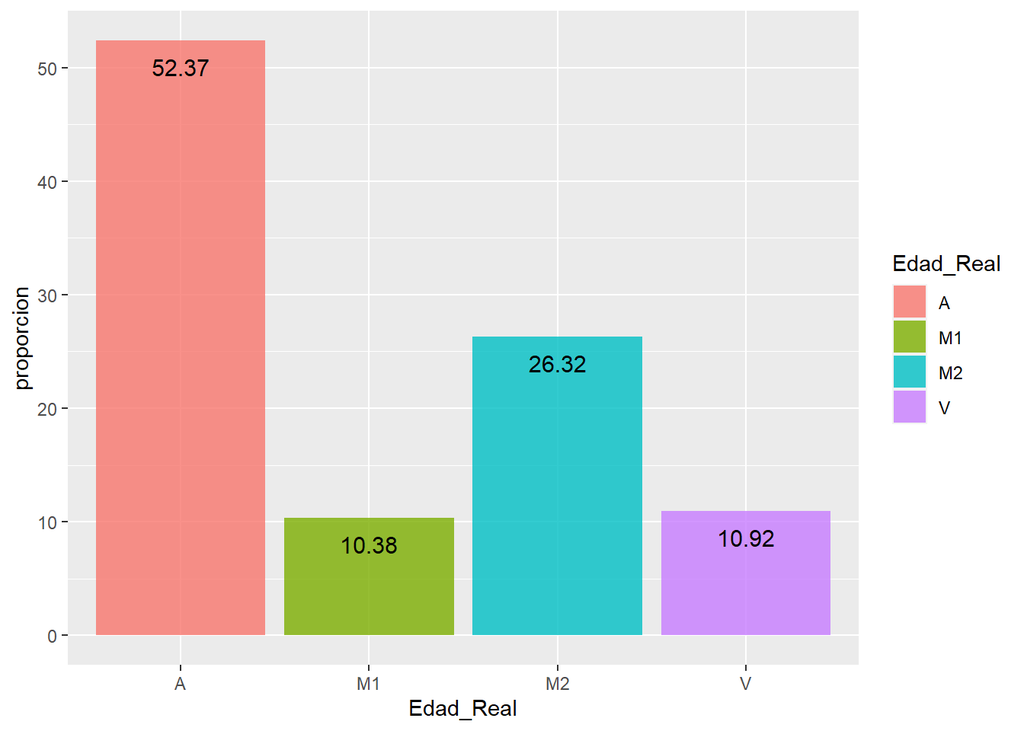

```r
BD_EP1 |>
group_by( Edad_Real) |>
  summarise(cantidad = n()) |>
  mutate(proporcion = cantidad/sum(cantidad)*100, proporcion=round(proporcion, 2) ) %>%
ggplot() +
  geom_col(aes(x = Edad_Real, y = proporcion, fill = Edad_Real),position = "dodge", alpha = 0.8)+
   geom_text(aes(x = Edad_Real, y = proporcion,label = proporcion), position =position_stack(), size=4, vjust=2, hjust=0.5, col="black")
```

### Composición de la tropa según Sexo

```r
BD_EP1 |>
  group_by(Sexo) |>
  summarise(cantidad = n()) |>
  mutate(proporcion = cantidad/sum(cantidad)*100, proporcion=round(proporcion, 2) ) %>%
gt() %>%
  tab_header(title = "Frencuencia y Porcentaje de Machos, Hembras y Capones")
```

Frencuencia y Porcentaje de Machos, Hembras y Capones

| Sexo | cantidad | proporcion |
| --- | --- | --- |
| C | 137 | 9.29 |
| H | 1235 | 83.79 |
| M | 102 | 6.92 |

### Composición de la tropa según Edad y Sexo

```r
BD_EP1 |>
  group_by(Sexo, Edad_Real) |>
  summarise(cantidad = n()) |>
  mutate(proporcion = cantidad/sum(cantidad)*100, proporcion=round(proporcion, 2) ) %>%
gt() %>%
  tab_header(title = "Frencuencia y Porcentaje de Machos, Hembras y Capones")
```

Frencuencia y Porcentaje de Machos, Hembras y Capones

| Edad_Real | cantidad | proporcion |
| --- | --- | --- |
| C |  |  |
| A | 50 | 36.50 |
| M1 | 21 | 15.33 |
| M2 | 66 | 48.18 |
| H |  |  |
| A | 703 | 56.92 |
| M1 | 96 | 7.77 |
| M2 | 280 | 22.67 |
| V | 156 | 12.63 |
| M |  |  |
| A | 19 | 18.63 |
| M1 | 36 | 35.29 |
| M2 | 42 | 41.18 |
| V | 5 | 4.90 |

```r
 # BD_EP1 %>%
 #   group_by(FM) %>%   #esta variable no la estamos trabajando
 #   summarise(cantidad = n()) %>%
 #   mutate(proporcion = cantidad/sum(cantidad)*100, proporcion=round(proporcion, 2) ) %>%
 # gt() %>%
 # tab_header(title = "Frecuencia y Porcentaje de Finura de Fibra")
```

```r
BD_EP4 <- dplyr::select(BD_EP1, "Condicion_Corporal", "Diametro_Fibra", "Sexo")

head(BD_EP4)
```

```
## # A tibble: 6 × 3
##   Condicion_Corporal Diametro_Fibra Sexo
##                <dbl>          <dbl> <chr>
## 1                  2           21.2 H
## 2                  3           26.5 H
## 3                  1           35.3 H
## 4                  1           38.3 H
## 5                  2           25.4 H
## 6                  4           28.5 H
```

```r
BD_EP4 |>
  group_by(Sexo) |>
  summarise(cantidad = n()) |>
  mutate(proporcion = cantidad/sum(cantidad)*100, proporcion=round(proporcion, 2) ) %>%
gt() %>%
  tab_header(title = "Frencuencia y Porcentaje de Machos, Hembras y Capones")
```

Frencuencia y Porcentaje de Machos, Hembras y Capones

| Sexo | cantidad | proporcion |
| --- | --- | --- |
| C | 137 | 9.29 |
| H | 1235 | 83.79 |
| M | 102 | 6.92 |

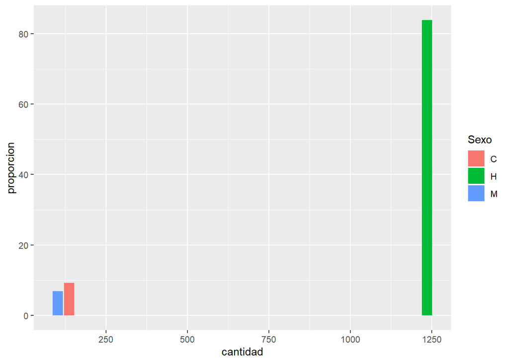

```r
BD_EP4 |>
  group_by(Sexo) |>
  summarise(cantidad = n()) |>
  mutate(proporcion = cantidad/sum(cantidad)*100, proporcion=round(proporcion, 2) ) %>%
 ggplot(aes(x = cantidad, y = proporcion)) +
  geom_col(aes(fill = Sexo))
```

```r
BD_EP2 <- dplyr::select(BD_EP1, "Condicion_Corporal", "Diametro_Fibra", "Edad_Real")%>%
  group_by(Edad_Real)%>%
  summarise(Frecuencia=length(Condicion_Corporal),
            Media_CC=mean(Condicion_Corporal,na.rm = TRUE),Media_CC=round(Media_CC, 2),
            #promedio_peso = round(mean(masa_corporal_g/1000, na.rm = TRUE), 2))
            Media_DF=mean(Diametro_Fibra,na.rm = TRUE),Media_DF=round(Media_DF, 2),
            Desvio_CC=sd(Condicion_Corporal,na.rm = TRUE),Desvio_CC=round(Desvio_CC, 2),
            Desvio_DF=sd(Diametro_Fibra,na.rm = TRUE),Desvio_DF=round(Desvio_DF, 2),
            Max_CC=max(Condicion_Corporal,na.rm = TRUE),Max_CC=round(Max_CC, 2),
            Max_DF=max(Diametro_Fibra,na.rm = TRUE),Max_DF=round(Max_DF, 2),
            Min_CC=min(Condicion_Corporal,na.rm = TRUE),Min_CC=round(Min_CC, 2),
            Min_DF=min(Diametro_Fibra,na.rm = TRUE),Min_DF=round(Min_DF, 2),
            Varianza_CC=var(Condicion_Corporal,na.rm = TRUE),Varianza_CC=round(Varianza_CC, 2),
            Varianza_DF=var(Diametro_Fibra,na.rm = TRUE),Varianza_DF=round(Varianza_DF, 2))

BD_EP2
```

```
## # A tibble: 4 × 12
##   Edad_Real Frecuencia Media_CC Media_DF Desvio_CC Desvio_DF Max_CC Max_DF
##   <chr>          <int>    <dbl>    <dbl>     <dbl>     <dbl>  <dbl>  <dbl>
## 1 A                772     2.53     24.8      0.88      3.42      4   40.8
## 2 M1               153     2.47     23.3      0.71      2.59      4   31.9
## 3 M2               388     2.54     24.2      0.76      3.08      4   33.8
## 4 V                161     2.24     26.2      0.89      3.82      5   39.0
## # … with 4 more variables: Min_CC <dbl>, Min_DF <dbl>, Varianza_CC <dbl>,
## #   Varianza_DF <dbl>
```

```r
BD_EP2 <- dplyr::select(BD_EP1, "Condicion_Corporal", "Diametro_Fibra", "Edad_Real")

BD_EP2
```

```
## # A tibble: 1,474 × 3
##    Condicion_Corporal Diametro_Fibra Edad_Real
##                 <dbl>          <dbl> <chr>
##  1                  2           21.2 M1
##  2                  3           26.5 A
##  3                  1           35.3 V
##  4                  1           38.3 V
##  5                  2           25.4 V
##  6                  4           28.5 V
##  7                  3           20.4 M2
##  8                  3           21.5 M2
##  9                  3           26.4 M2
## 10                  2           27.3 V
## # … with 1,464 more rows
```

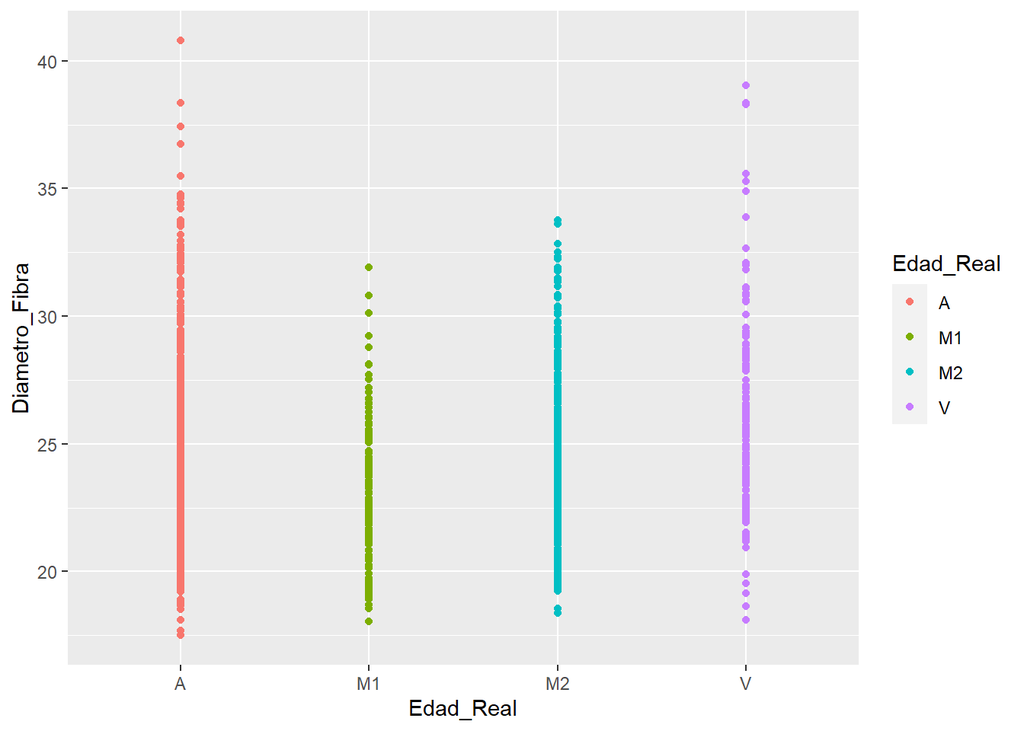

```r
ggplot(BD_EP1, aes(x=Edad_Real, y=Diametro_Fibra)) +
  geom_point(aes(color = Edad_Real))
```

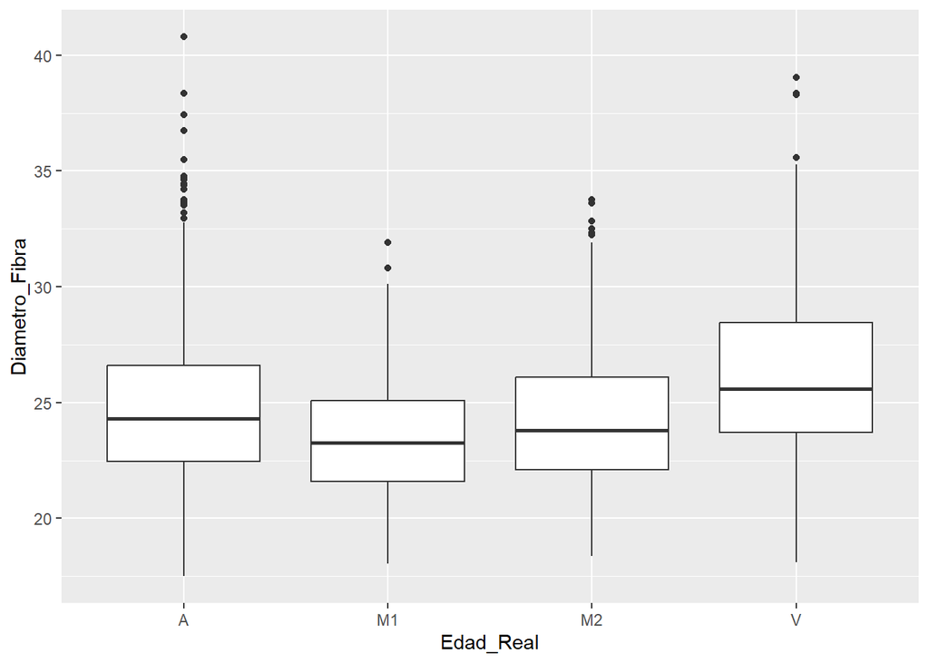

```r
ggplot(BD_EP1, aes(x=Edad_Real, y=Diametro_Fibra)) +
  geom_boxplot()
```

#Análisis de la Relación entre Edad y Diámetro de la fibra

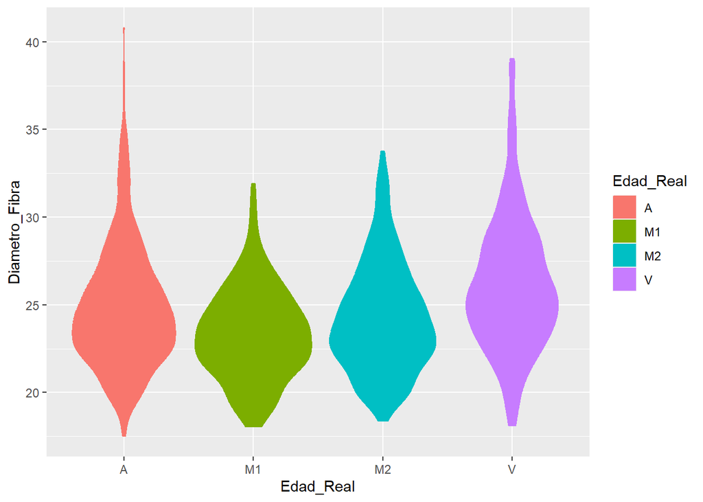

```r
ggplot(BD_EP1, aes(x=Edad_Real, y=Diametro_Fibra)) +
  geom_violin(aes(color = Edad_Real, fill = Edad_Real))
```

#